# Evaluating classification models

Anil

2026-08-24

# Introduction: A Doctor’s Dilemma

Imagine you are a doctor with **100 patients**:

- 20 actually have a disease (sick)
- 80 are healthy

You have a diagnostic machine that gives either:

- **Positive** → “You may have the disease.”
- **Negative** → “You probably don’t have the disease.”

The machine produces these results:

|  | **Sick** | **Healthy** |
| --- | --- | --- |
| **Positive** result | 18 | 10 |
| **Negative** result | 2 | 70 |

From this table we can identify:

- **True Positive (TP)** = 18 (sick and correctly detected)
- **False Negative (FN)** = 2 (sick but missed)
- **False Positive (FP)** = 10 (healthy but incorrectly flagged)
- **True Negative (TN)** = 70 (healthy and correctly cleared)

# The Confusion Matrix

A confusion matrix is a handy way to summarise the performance of a binary classifier.

```
                 ACTUAL
             Sick       Healthy
           ┌──────────┬──────────┐
Predicted  │          │          │
   Sick    │    TP    │    FP    │
           │          │          │
           ├──────────┼──────────┤
Predicted  │          │          │
 Healthy   │    FN    │    TN    │
           │          │          │
           └──────────┴──────────┘
```

# Sensitivity (also called Recall)

**Question:** *“Of all the people who actually had the disease, how many did our machine catch?”*

There were 20 sick people, and the machine caught 18.

$$\text{Sensitivity} = \frac{TP}{TP + FN} = \frac{18}{18 + 2} = 90\%$$

**Interpretation:** A high-sensitivity test is crucial when **missing a sick person is dangerous** (e.g., screening for a life-threatening disease).

## Why “Recall” is the Same

In information retrieval and machine learning, **recall** is the identical quantity:

$$\text{Recall} = \frac{TP}{TP + FN}$$

Both measure the ability to find *all* relevant (or sick) cases.  
The difference is purely contextual:

- **Medical diagnosis** → usually **Sensitivity**
- **Search / ML** → usually **Recall**

# Specificity

**Question:** *“Of all the healthy people, how many did our machine correctly identify as healthy?”*

There were 80 healthy people, and the machine correctly cleared 70.

$$\text{Specificity} = \frac{TN}{TN + FP} = \frac{70}{70 + 10} = 87.5\%$$

**Interpretation:** A highly specific test produces **few false alarms**.  
Think of airport security: you want to let innocent passengers through without unnecessary delays.

# Precision

**Question:** *“The machine predicted positive for 28 people. How many of those actually had the disease?”*

The machine predicted positive for $18 + 10 = 28$. Only 18 were truly sick.

$$\text{Precision} = \frac{TP}{TP + FP} = \frac{18}{18 + 10} \approx
64.3\%$$

**Interpretation:** When the machine says “yes,” how often is it right?  
This matters when **false positives are costly** (e.g., unnecessary treatment, wasted resources).

# Accuracy

**Question:** *“Out of all 100 patients, how many did the machine get right overall?”*

The machine correctly identified **18 sick** and **70 healthy**, for a total of 88 correct.

$$\text{Accuracy} = \frac{TP + TN}{TP + TN + FP + FN} = \frac{18 + 70}{18
+ 70 + 10 + 2} = \frac{88}{100} = 88\%$$

**Interpretation:** Accuracy is the overall success rate of the test.

## ⚠️ The Big Warning – Accuracy Can Lie!

Accuracy seems great (88%), but imagine a **lazy machine** that just says **“Healthy” to everyone**.

It would get:

- All 80 healthy patients correct → 80 correct
- All 20 sick patients wrong → 20 wrong

Its accuracy would be:

$$\text{Accuracy} = \frac{80}{100} = 80\%$$

**80% accuracy looks good, but the machine missed every single sick person!**

That is why, with **imbalanced data** (where one class is much rarer than the other), accuracy is misleading. In such cases, **Sensitivity, Specificity, and Precision** are much more informative.

# Table

[output not shown]

A common combined metric is the **F1 score**, the harmonic mean of precision and recall, used when you need a balance between them.

# Summary

| Role | Key Concern |
| --- | --- |
| Doctor | “Did I catch the sick people?” → Sensitivity/Recall |
| Airport Security | “Did I correctly clear the innocent?” → Specificity |
| Hospital Manager | “How reliable is a positive result?” → Precision |
| Patient | “If I’m sick, will the test find me?” → Sensitivity |
| Hospital CEO | “Overall, how often are we right?” → Accuracy |

These five metrics are foundational to evaluating any binary classification system, from medical tests to search engines to fraud detection.

# Introduction ROC

You’ve built your machine learning model – so what’s next? You need to evaluate and validate how good (or bad) it is, so you can decide whether to implement it. That’s where the **AUC-ROC curve** comes in.

The name might be a mouthful, but it is just saying that we are calculating the **Area Under the Curve** (AUC) of the **Receiver Operating Characteristic** (ROC).

**In short:** The AUC-ROC curve helps us visualise how well our binary classification model performs. It shows the trade-off between **True Positive Rate** and **False Positive Rate** at various classification thresholds.

# What is the AUC-ROC Curve?

- **ROC Curve** (Receiver Operating Characteristic): A graphical plot that illustrates the diagnostic ability of a binary classifier as its discrimination threshold is varied.
- **AUC** (Area Under the Curve): A single scalar value that summarises the entire ROC curve. It measures the overall performance of the classifier.

## Key Interpretations of AUC

| AUC Value | Meaning |
| --- | --- |
| **1.0** | Perfect classifier – separates all positive and negative instances. |
| **0.9 – 0.99** | Excellent discrimination. |
| **0.8 – 0.9** | Good discrimination. |
| **0.7 – 0.8** | Fair discrimination. |
| **0.5** | No discrimination – random guessing (diagonal line). |
| **< 0.5** | Worse than random – possibly reverse predictions. |

# The Confusion Matrix and Key Metrics

Before diving into the ROC curve, we must recall the confusion matrix and its derived metrics.

```
                ACTUAL
             Positive   Negative
Predicted    ┌─────────┬─────────┐
  Positive   │   TP    │   FP    │
             ├─────────┼─────────┤
  Negative   │   FN    │   TN    │
             └─────────┴─────────┘
```

- **True Positive (TP)**: Correctly predicted positive.
- **False Negative (FN)**: Missed positive.
- **False Positive (FP)**: Incorrectly predicted positive.
- **True Negative (TN)**: Correctly predicted negative.

## Important Derived Metrics

Total population = P+N

True positive rate (TPR)= TP/P

False positive rate (FPR)= FP/N

- **Sensitivity (Recall, True Positive Rate, TPR)** = TP / (TP + FN)  
  *Proportion of actual positives correctly identified.*
- **Specificity (True Negative Rate, TNR)** = TN / (TN + FP)  
  *Proportion of actual negatives correctly identified.*
- **False Positive Rate (FPR)** = FP / (TN + FP) = 1 - Specificity  
  *Proportion of actual negatives incorrectly classified as positive.*
- **False Negative Rate (FNR)** = FN / (TP + FN) = 1 - Sensitivity

The ROC curve plots **TPR (Sensitivity) on the y-axis** vs. **FPR (1 - Specificity) on the x-axis** at various threshold settings.

# Why Use Probabilities Instead of Hard Predictions?

A classification model can output a probability of belonging to the positive class. By changing the threshold (e.g., from 0.5 to 0.7), we can adjust the trade-off between sensitivity and specificity. The ROC curve captures this trade-off across all possible thresholds, giving a complete picture of the model’s performance.

# How Does the AUC-ROC Curve Work?

- The **diagonal line** from (0,0) to (1,1) represents a random classifier (AUC = 0.5).
- Points **above** the diagonal indicate better-than-random performance.
- The **top-left corner** (0,1) represents a perfect classifier (100% sensitivity, 100% specificity).
- The **closer the curve to the top-left corner**, the better the model.

## Interpreting Points on the ROC Curve

- **Point A**: High sensitivity, but also high FPR.
- **Point B**: Same sensitivity as A, but lower FPR → better.
- **Point C**: Higher sensitivity than D for the same FPR → better.
- **Point E**: Maximum specificity (no false positives) – useful when false positives are very costly.

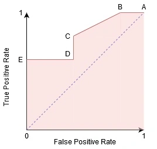

The choice of the optimal threshold depends on the business problem: minimising false negatives (e.g., disease screening) or minimising false positives (e.g., spam detection).

| Score | Actual |
| --- | --- |
| 0.98 | 0 |
| 0.89 | 0 |
| 0.86 | 0 |
| 0.86 | 0 |
| 0.85 | 1 |
| 0.82 | 1 |
| 0.79 | 0 |
| 0.78 | 0 |
| 0.67 | 1 |
| 0.58 | 1 |

| Actual | Threshold | TP | FN | FP | TN | TPR | FPR | ROC Point |
| --- | --- | --- | --- | --- | --- | --- | --- | --- |
| 0 | ∞ | 0 | 4 | 0 | 6 | 0.000 | 0.000 | (0, 0) |
| 0 | 0.98 | 0 | 4 | 1 | 5 | 0.000 | 0.167 | (0.167, 0) |
| 0 | 0.89 | 0 | 4 | 2 | 4 | 0.000 | 0.333 | (0.333, 0) |
| 0 | 0.86 | 0 | 4 | 4 | 2 | 0.000 | 0.667 | (0.667, 0) |
| 1 | 0.85 | 1 | 3 | 4 | 2 | 0.250 | 0.667 | (0.667, 0.25) |
| 1 | 0.82 | 2 | 2 | 4 | 2 | 0.500 | 0.667 | (0.667, 0.50) |
| 0 | 0.79 | 2 | 2 | 5 | 1 | 0.500 | 0.833 | (0.833, 0.50) |
| 0 | 0.78 | 2 | 2 | 6 | 0 | 0.500 | 1.000 | (1, 0.50) |
| 1 | 0.67 | 3 | 1 | 6 | 0 | 0.750 | 1.000 | (1, 0.75) |
| 1 | 0.58 | 4 | 0 | 6 | 0 | 1.000 | 1.000 | (1, 1) |

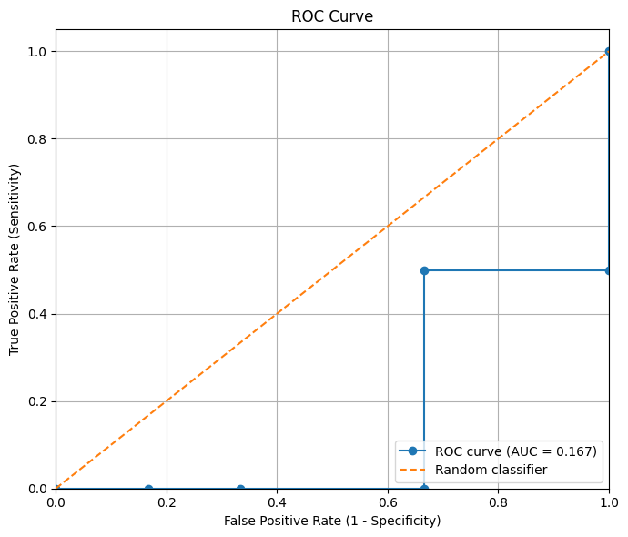

# Summary

- **AUC-ROC** is a powerful metric to evaluate binary classifiers.
- It provides a trade-off between **Sensitivity** and **Specificity** across all thresholds.
- **AUC** summarises the model’s discriminative ability: higher AUC means better separation.
- In R, the **`ROCR`** package is a classic tool for computing and plotting ROC curves.
- For multi-class problems, use the **One-vs-Rest** approach (e.g., with `pROC::multiclass.roc` or manual loops).

# Log Likelihood

Probability predictions contain more information than just YES/NO.

Consider a spam email.

### Model A

```
P(spam) = 0.98
```

### Model B

```
P(spam) = 0.52
```

Both may classify the email as spam at a 0.5 threshold.

But Model A is much more confident.

Log likelihood evaluates how well predicted probabilities match the actual class labels.

# Why Log Likelihood Penalizes Bad Confidence

For a real spam email:

```
P(spam) = 0.98
```

Contribution:

$$\log(0.98) \approx -0.02$$

Very good.

But:

```
P(spam) = 0.02
```

Contribution:

$$\log(0.02) \approx -3.9$$

Much worse.

### Key idea

A model is strongly penalized when it is **confidently wrong**.

We have to note that values closer to zero indicate better log likelihood.

# Deviance

For probability models, another measure is **deviance**.

Conceptually:

> Deviance measures how much unexplained error remains relative to a perfect/saturated model.

### Rule of thumb

**Lower deviance → better model**